# BS2280 – Econometrics I

# Homework 4: Hypothesis testing - Solution

## Question 1

A researcher hypothesises that years of schooling, $S$, may be related to the number of siblings (brothers and sisters), $SIBLINGS$, according to the relationship

$$\begin{equation*}
S=\beta_{1}+\beta_{2}SIBLINGS+u
\end{equation*}$$

She is prepared to test the null hypothesis $H_0:\beta_{2}=0$ against the alternative hypothesis $H_1:\beta_{2}\neq 0$ at the 5% and 1% levels. She has a sample of 60 observations.

The critical t values at the 5% and 1% significance level are 2.00 and 2.66 respectively. Undertake hypothesis tests for the following scenarios:

1. $\hat{\beta}_{2}=-0.20$, s.e.$(\hat{\beta}_{2})=0.07$
2. $\hat{\beta}_{2}=-0.12$, s.e.$(\hat{\beta}_{2})=0.07$
3. $\hat{\beta}_{2}=0.06$, s.e.$(\hat{\beta}_{2})=0.07$
4. $\hat{\beta}_{2}=0.20$, s.e.$(\hat{\beta}_{2})=0.07$

To test whether any of the coefficients provided above are statistically significant, we need to follow these steps:

1. State the null and alternative hypotheses
2. Select the significance level
3. Select and calculate the test statistics
4. Set the decision rule
5. Make statistical decisions

Now we look at this question.

Step 3: calculate the t-values, which measure how many standard errors is our coefficient away from zero.

$$\begin{equation*}
t=\frac{\hat{\beta}_{2}-\beta_{2}^0}{s.e.(\hat{\beta}_{2})}
\end{equation*}$$

Please note:

- Our test is two-tailed, so the non-rejection area has a left boundary of -2.00 at the 5% significance level and -2.66 at the 1% significance level. The right boundary is +2.00 for 5% and +2.66 for 1% significance level.

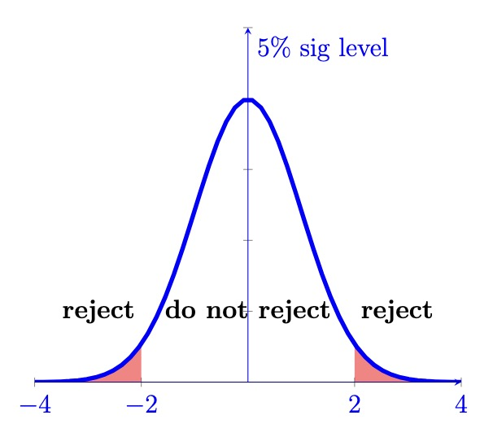

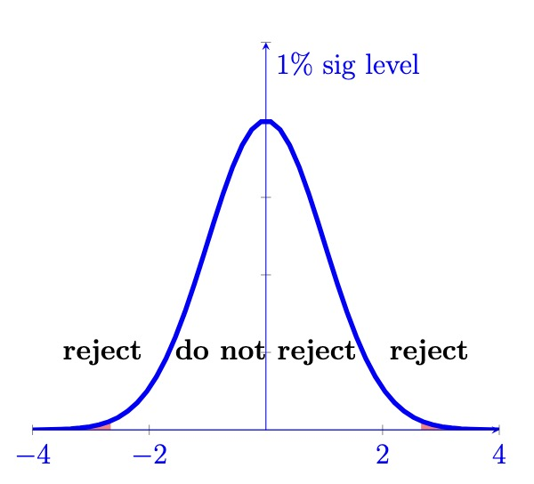

- Looking at the critical values shows that to reject the null Hypothesis at a lower significance level, the t-value has to be greater than for a higher significance level! Therefore the non-rejection area at the 1% significance level is wider than at the 5% significance level.
- If you can reject the $H_0$ at the 1% significance level, you can always reject it also at the 5% significance level, but if you can reject it at the 5% level does not mean that you can also reject it at the 1% significance level!
- To get full points in the coursework, ensure that you complete the 5 steps of Hypothesis testing.

Step 5: Make decisions

Step 1. We know the null hypothesis is $H_0:\beta_{2}=0$ and alternative hypothesis is $H_1:\beta_{2}\neq 0$.

Step 2. The significance levels are 5% and 1%.

Step 4: The decision rule is: If the absolute value of t-value is greater than the critical value, then we can reject the null Hypothesis and our coefficient is statistically significant.

Now we calculate the t-values in step 3 and undertake hypothesis tests for the following scenarios:

1. $\hat{\beta}_{2}=-0.20$, s.e.$(\hat{\beta}_{2})=0.07$

Null hypothesis: $H_0:\beta_{2} = 0$; Alternative hypothesis: $H_1:\beta_{2}\neq 0$

$t=\frac{\hat{\beta}_{2}-\beta_{2}^0}{s.e.(\hat{\beta}_{2})} \approx -2.857$

At the 1% level, the left critical value is -2.66, so t-value falls into the left reject area, therefore we reject $H_0$ at the 1% level.

Because we reject it at the 1% level, we already know that we can also reject it at the 5% level.

2. $\hat{\beta}_{2}=-0.12$, s.e.$(\hat{\beta}_{2})=0.07$

Null hypothesis: $H_0:\beta_{2} = 0$; Alternative hypothesis: $H_1:\beta_{2}\neq 0$

$t=\frac{\hat{\beta}_{2}-\beta_{2}^0}{s.e.(\hat{\beta}_{2})} \approx -1.714$

At the 5% level, this t-value falls within non-rejection area, therefore we cannot reject $H_0$ at the 5% level.

As we cannot reject $H_0$ at the 5% level, we already know that we also cannot reject it at the 1% level!

3. $\hat{\beta}_{2}=0.06$, s.e.$(\hat{\beta}_{2})=0.07$

Null hypothesis: $H_0:\beta_{2} = 0$; Alternative hypothesis: $H_1:\beta_{2}\neq 0$

$t=\frac{\hat{\beta}_{2}-\beta_{2}^0}{s.e.(\hat{\beta}_{2})} \approx 0.857$

At the 5% level, t-value falls within non-rejection area, therefore we cannot reject $H_0$ at the 5% level.

As we cannot reject $H_0$ at the 5% level, we already know that we also cannot reject it at the 1% level!

4. $\hat{\beta}_{2}=0.20$, s.e.$(\hat{\beta}_{2})=0.07$

Null hypothesis: $H_0:\beta_{2} = 0$; Alternative hypothesis: $H_1:\beta_{2}\neq 0$

$t=\frac{\hat{\beta}_{2}-\beta_{2}^0}{s.e.(\hat{\beta}_{2})} \approx 2.857$

At the 1% level,the right critical value is 2.66, so t-value falls within reject area, therefore we reject $H_0$ at the 1% level.

Because we reject it at the 1% level, we already know that we can also reject it at the 5% level.

## Question 2

The number of cigarettes smoked per day is regressed on the price of cigarettes per pack in USD. Sample size $n=807$.

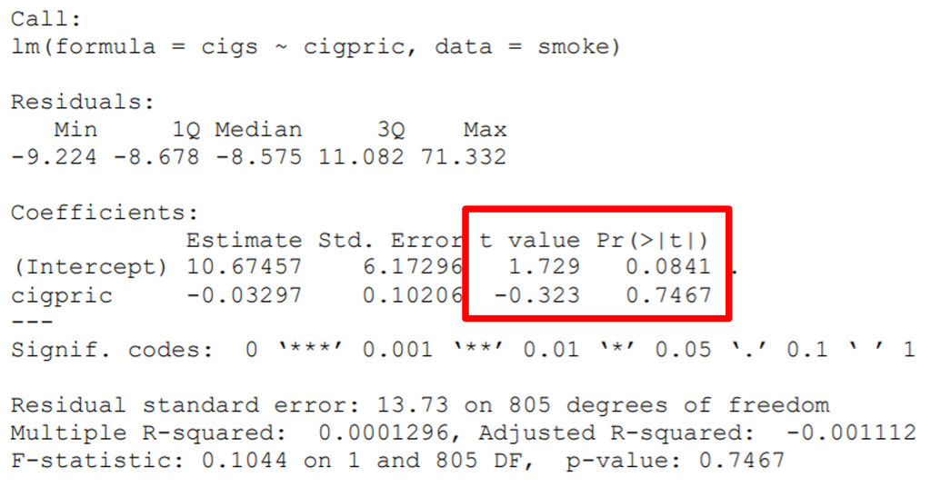

$H_0:\beta_{1}=0$, $H_1:\beta_{1}\neq 0$

$H_0:\beta_{2}=0$, $H_1:\beta_{2}\neq 0$

- Intercept: $t-value = \frac{\hat{\beta}_{1}-\beta_{1}^0}{s.e.(\hat{\beta}_{1})}=\approx 1.729$ < $t_{crit,5\%}= 1.96$

We cannot reject $H_0$. The intercept is statistically insignificant.

- Cigprice: $t-value = \frac{\hat{\beta}_{2}-\beta_{2}^0}{s.e.(\hat{\beta}_{2})} \approx -0.323$ > $t_{crit,5\%}=-1.96$

We cannot reject $H_0$. The coefficient of cigarette price is statistically insignificant.

## Question 3

Calculate the 95% confidence interval for the intercept as well as the coefficient of cigarette prices using the R output in Question 2.

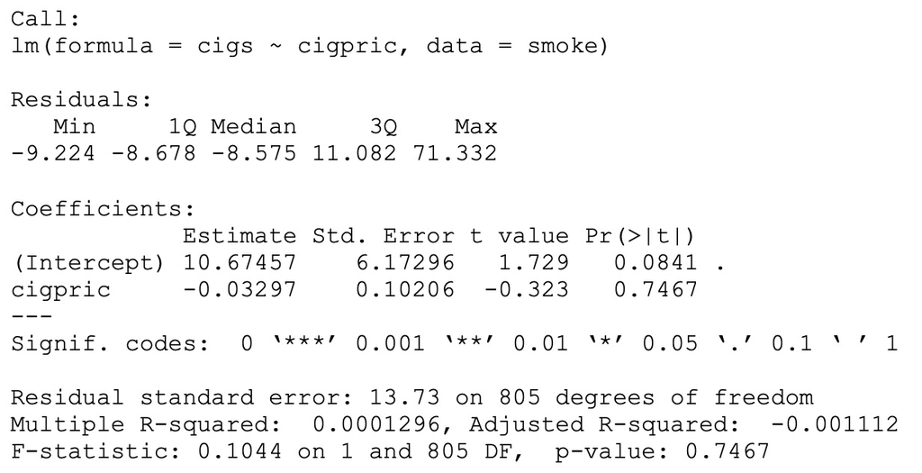

The formula for calculating the confidence interval for the intercept is
$$\begin{equation*}
\hat{\beta}_{1}-s.e.(\hat{\beta}_{1}) \times t_{crit,5\%} \leq
\beta_{1} \leq \hat{\beta}_{1}+s.e.(\hat{\beta}_{1}) \times
t_{crit,5\%}
\end{equation*}$$

The formula for calculating the confidence interval for the cigarette coefficient is

$$\begin{equation*}
\hat{\beta}_{2}-s.e.(\hat{\beta}_{2}) \times t_{crit,5\%} \leq
\beta_{2} \leq \hat{\beta}_{2}+s.e.(\hat{\beta}_{2}) \times
t_{crit,5\%}
\end{equation*}$$

The regression output shows that the point estimate $\hat{\beta}_{1}$ is 10.67457 and its standard error $s.e.(\hat{\beta}_{1})$ is 6.17296.

$$\begin{equation*}
10.67457-6.17296 \times 1.96 \leq \beta_{1} \leq 10.67457+6.17296
\times 1.96
\end{equation*}$$

The regression output shows that the point estimate $\hat{\beta_{2}}$ is -0.03297 and its standard error $s.e.(\hat{\beta}_{2})$ is 0.10206.

$$\begin{equation*}
-0.03297-0.10206 \times 1.96 \leq \beta_{2} \leq -0.03297+ 0.10206
\times 1.96
\end{equation*}$$

## Question 4

Calculate the F statistic for the regression undertaken in Question 2 using $ESS$ and $RSS$ presented in the R anova output table above. Check that the F statistic derived from $R^2$ is the same. Perform the F test, whereby the critical F-value at the 5% significance level is approximately 3.8415.

The formula for the F-statistics are
$$\begin{equation*}
F(1,805)=\frac{ESS/(k-1)}{RSS/(n-k)}
\end{equation*}$$

or

$$\begin{equation*}
F(1,805)=\frac{R^2/(k-1)}{(1-R^2)/(n-k)}
\end{equation*}$$

The regression output is

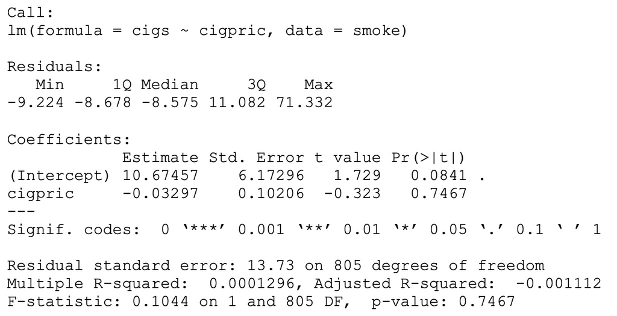

and

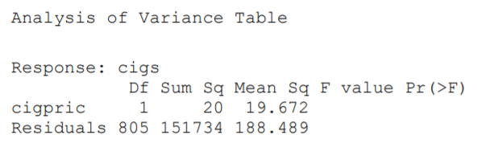

We follow hypothesis testing five steps:

Step 1: the null hypothesis is $H_0:R^2=0$ and alternative hypothesis is $H_1:R^2\neq 0$.

Step 2: the significance level is 5%.

Step 3: calculate the F-values using either formula

$$\begin{equation*}
F(1,805) \approx 0.104 < F_{crit,5\%}=3.8415
\end{equation*}$$

Step 5: Make decisions

Step 3: calculate the F-values using either formula

$ESS=20$

$RSS=151734$

$k=2$

$n=807$

$R^2=0.0001296$

$F(1,805)=\frac{ESS/(k-1)}{RSS/(n-k)} \approx 0.106$

$F(1,805)=\frac{R^2/(k-1)}{(1-R^2)/(n-k)} \approx 0.104$

Step 4: The decision rule is: If the F-value is greater than the $F_{crit,5\%}$ then we can reject the null Hypothesis, so our model is statistically significant.

Step 5: Make decisions Therefore we cannot reject the $H_0$ and our model is statistically insignificant.

## Question 5

The number of cigarettes per day is regressed on the age of participants. Use the R output tables below to answer Questions 2 – 4 again.

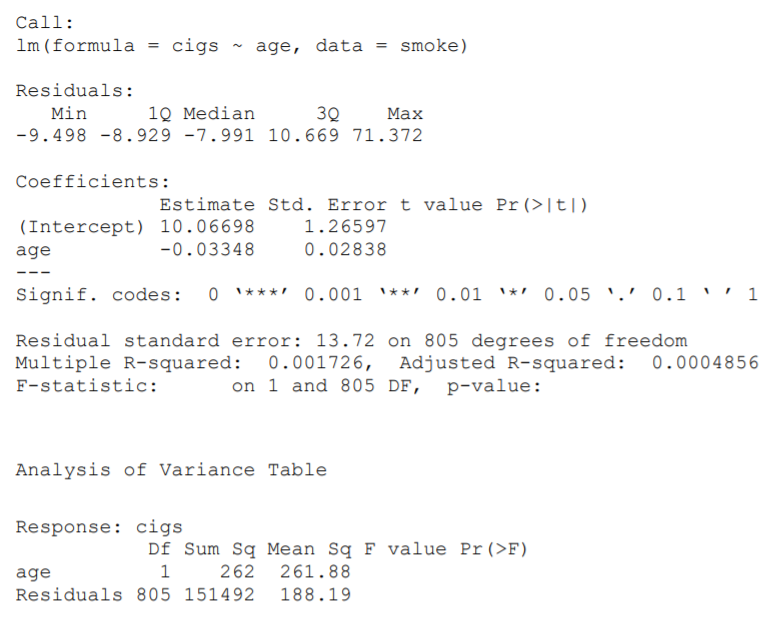

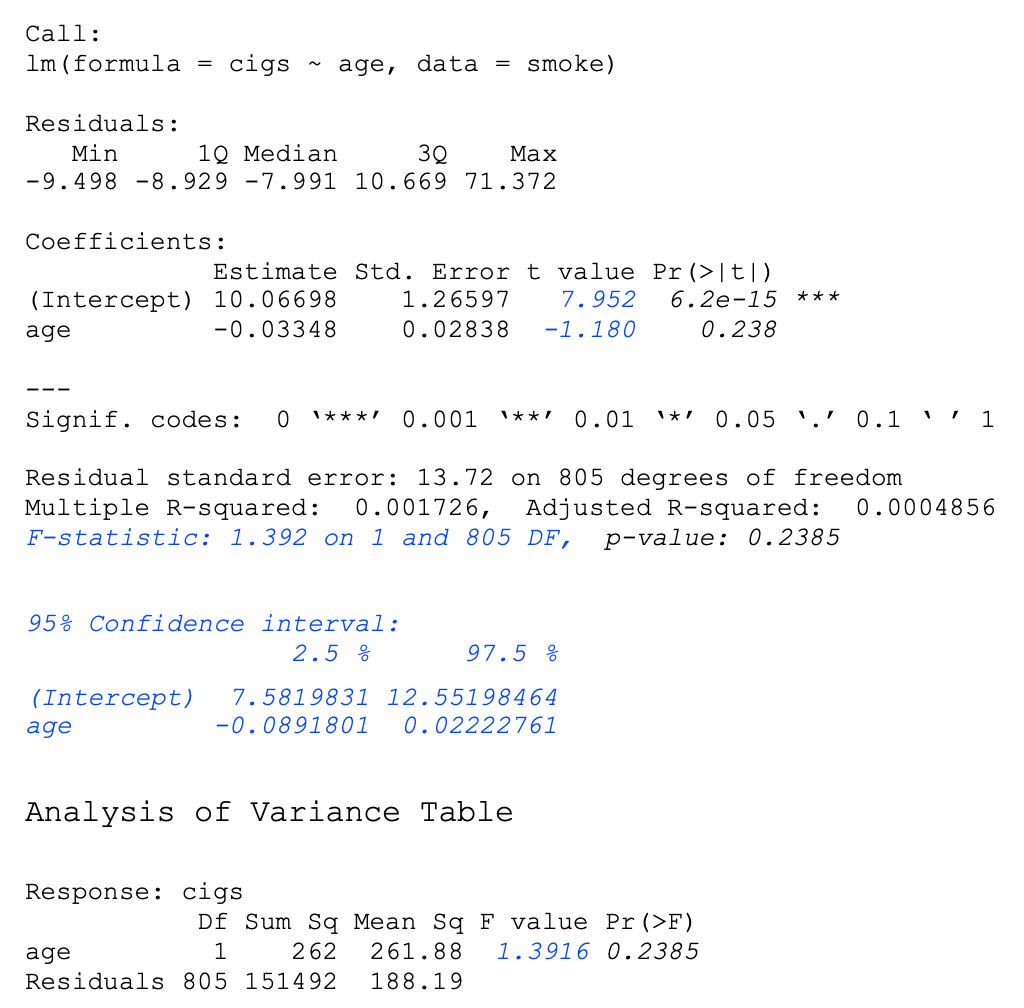